# MASTER MODE : UE MDET : DYNAMIQUES EVOLUTIVES

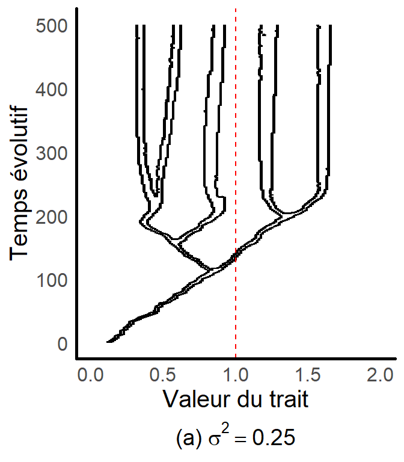

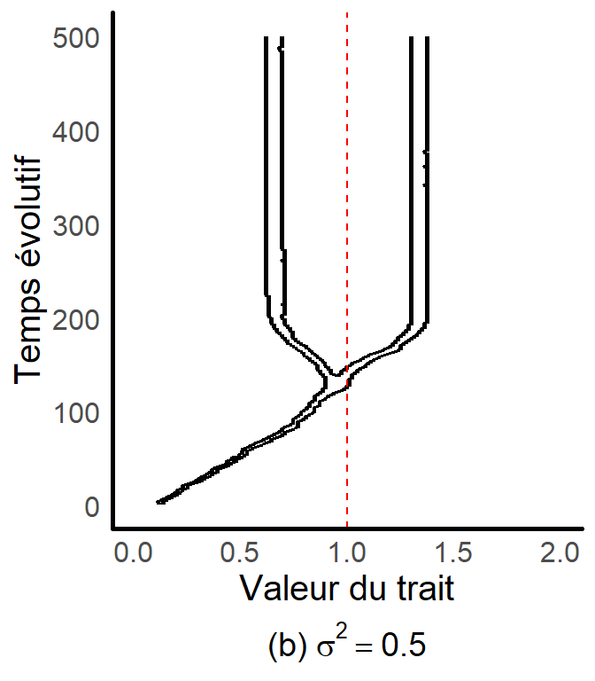

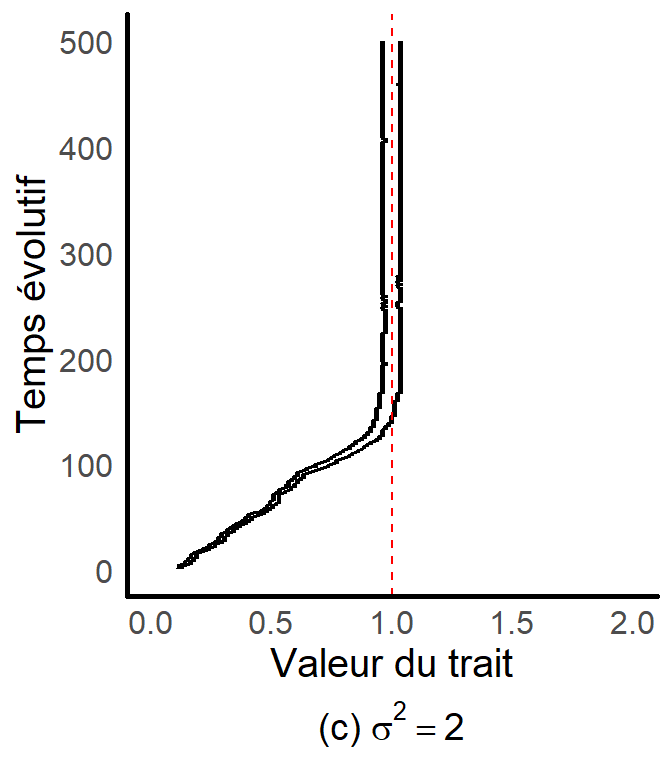

```r
sortie_raster(nT = nT_025, caption = TeX("(a) $\\sigma^2 = 0.25$"))

sortie_raster(nT = nT_05, caption = TeX("(b) $\\sigma^2 = 0.5$"))

sortie_raster(nT = nT_2, caption = TeX("(c) $\\sigma^2 = 2$"))
```

En partant d’une population monomorphe, les mutations ont permis de créer une dynamique évolutive. La valeur de trait de départ était suboptimale ($x_{initial} = 0.11$ et $x_0 = x* = 1$) on a donc observé pour les 3 simulations une première convergence vers la valeur de trait optimal $x*$ (ligne rouge). Ensuite, la valeur du paramètre $\sigma ^2$ modulait les trajectoires évolutives. Lorsque l’intensité de compétition était faible (graphiques **(a)** et **(b)**), des embranchements évolutifs ont pu être mis en évidence meanant à une population polymorphique (graphique a) lorsque l’intensité de la compétition était à son plus bas et dimorphique (graphique b) lorsque l’intensité de compétition était un peu plus élevée. Dans le cas où le paramètre $\sigma^2$ était le plus élevée (graphique c), aucun embranchement évolutif n’a été observé. Ces résultats corroborent les conclusions de la partie précédente sur la modulation du paramètre $\sigma$ sur le taux de fixation ds phénotypes dans la population, avec une intensité de compétition élevée entravant proportionnellement le nombre de phénotypes fixés dans la population.

*NOTE - on remarque que la simulation du graphique (a) n’est pas totalement stabilisée (des branches pourraient à terme se créer ou fusionner), cependant pour des raisons de temps de calcul, nous avons décidé de pas ne lancer la simulation plus loin*.